# R語言與資料科學導論期中考（2017 Autumn）

b05b02048 生技系 楊崴光

### 注意事項：

- 請記得在上方的author處，寫下您的學號、學系、姓名
- 作答過程中，您可以自由查閱各種資料：課堂講義、網路資源、個人檔案、筆記等材料。但**「不能」**向其他人尋求協助。
- 每一題都已經預留作答的程式區塊（code chunks，區塊名稱為ans.#.#）。除第二大題的2.2有2個區塊外，每一小題都各有一個區塊。 為了讓每份答卷格式統一，請您不要自行增加、刪除程式區塊。
- 所有題目都必須要在程式區塊中詳列作答過程。
- 請注意每一題輸出的格式要求。作圖題皆須加上圖形的主標題和X或Y軸標籤。 在第二大題中，除2.2的第一小題是輸出圖形(plot)外，每個程式區塊都有用來印出答案的程式碼，請用它們來呈現答案。感謝配合。
- 答卷繳交方式如同一般作業，請您將整份檔案knit成HTML檔後上傳CEIBA。

```r
knitr::opts_chunk$set(echo=TRUE, error=TRUE)
```

```r
library(httr)
library(readr)
library(dplyr)
library(jiebaR)
```

# 一、程式碼填空（40%）

在這一大題中，每一題都已經有大部分的程式結構，您只需要把有些空白的部分（如<BLANK.1.1>）， 代換成正確的程式碼，讓整段程式可以正確執行。

**請把整段程式複製到作答區，並把所有的空白處代換成正確的程式碼。請勿更改非空白部分（<BLANK.#.#>以外的部分）的程式碼**

## 1.0 作答範例

`data.1`有5個數值，請算出他們的平均數。

```
data.1 <- c(10,12,16,20,14)
avg <- <BLANK.0.1>(data.1)
print(avg)
```

請把上述整段程式複製到以下的作答區，並把<BLANK.0.1>代換成正確的程式碼（`mean`）即可。

```r
data.1 <- c(10,12,16,20,14)
avg <- mean(data.1)
print(avg)
```

```
## [1] 14.4
```

## 1.1 條件式 (5%)

請完成以下 `pick_apple` 函數。該函數只有一個參數，當參數是“apple”時（即`pick_apple("apple")`）， 函數要回傳 `"apple found"`；若是所有其他的字串，則函數要回傳 `"nothing"`。

```
pick_apple <- function(argStr){
    if (<BLANK.1.1>) {
        return(<BLANK.1.2>)
    } else {
        return(<BLANK.1.3>)
    }
}
pick_apple("apple")
```

```r
# copy-paste the code above and fill out the blank
pick_apple <- function(argStr){
    if (argStr == "apple") {
        return("apple found")
    } else {
        return("nothing")
    }
}
pick_apple("apple")
```

```
## [1] "apple found"
```

## 1.2 散佈圖(5%)

請用內建的`mtcars`資料集，畫出mpg變項（X軸）與hp變項（Y軸）的散佈圖。 散佈圖中的每一個點都是實心的藍色。 這張散佈圖需有標題 `"Scatter plot of Miles/gallon and Hourse Power"`， X軸標籤 `"Miles/gallon"` ， Y軸標籤 `"Horsepower"`。

```
plot(<BLANK.2.1>, <BLANK.2.2>,
     <BLANK.2.3>="Miles/gallon", <BLANK.2.4>="Horsepower",
     <BLANK.2.5>="Scatter plot of Miles/gallon and Hourse Power",
     <BLANK.2.6>="blue", pch=16)
```

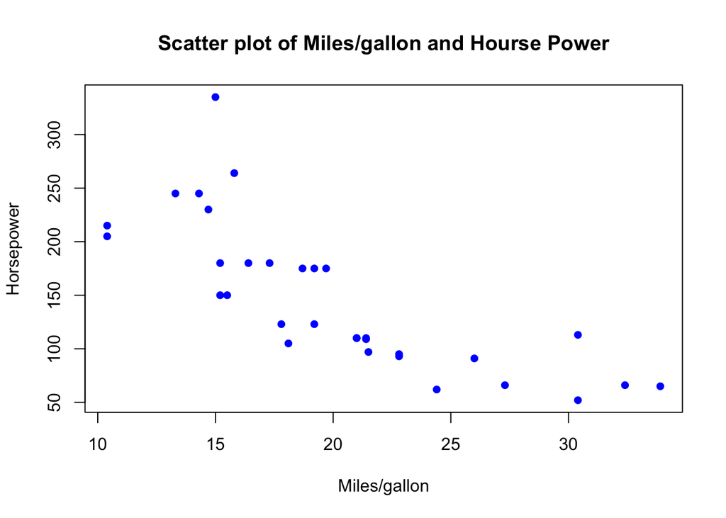

```r
# copy-paste the code above and fill out the blank
plot(mtcars$mpg, mtcars$hp,
     xlab = "Miles/gallon", ylab = "Horsepower",
     main = "Scatter plot of Miles/gallon and Hourse Power",
     col ="blue", pch=16)
```

## 1.3 資料篩選（filter）(5%)

請用dplyr選出內建資料集`Orange`的`Tree`和`circumference`兩個變項， 並篩選出所有`Tree`變項的值是3的資料。

```
Orange %>%
    <BLANK.3.1>(Tree, circumference) %>%
    <BLANK.3.2>(Tree == 3)
```

```r
# copy-paste the code above and fill out the blank
Orange %>%
    select(Tree, circumference) %>%
    filter(Tree == 3)
```

```
##   Tree circumference
## 1    3            30
## 2    3            51
## 3    3            75
## 4    3           108
## 5    3           115
## 6    3           139
## 7    3           140
```

## 1.4 資料分組與摘要（grouping）(5%)

請用dplyr對內建資料集`Orange`的`Tree`變項分組， 並找出每組最大的周長（`circumference`變項）及最小周長的差異。 最後將結果按照周長的差異由大到小排序。

```
Orange %>%
    <BLANK.4.1>(Tree) %>%
    <BLANK.4.2>(cir.diff=max(circumference)-<BLANK.4.3>(circumference)) %>%
    <BLANK.4.4>(desc(cir.diff))
```

```r
# copy-paste the code above and fill out the blank
Orange %>%
    group_by(Tree) %>%
    summarise(cir.diff=max(circumference)-min(circumference)) %>%
    arrange(desc(cir.diff))
```

```
## # A tibble: 5 x 2
##    Tree cir.diff
##   <ord>    <dbl>
## 1     4      182
## 2     2      170
## 3     5      147
## 4     1      115
## 5     3      110
```

## 1.5 字串擷取與分割（split）(5%)

`textStr`字串中包含電話與EMail，請先用逗號分割字串，並取出其中的電話號碼。

```
textStr <- "Alice, Taiwan, TEL:02-33663366, EMail: anonymous@ntu.edu.tw"
# split the string
fieldValues <- <BLANK.5.1>(textStr, <BLANK.5.2>)[[1]]

# extract the substring
TEL <- <BLANK.5.3>(fieldValues[3], 6, <BLANK.5.4>(fieldValues[3]))

print(sprintf("telephone number: %s", TEL))
```

```r
# copy-paste the code above and fill out the blank
textStr <- "Alice, Taiwan, TEL:02-33663366, EMail: anonymous@ntu.edu.tw"
# split the string
fieldValues <- strsplit(textStr, ",")[[1]]

# extract the substring
TEL <- substr(fieldValues[3], 6, nchar(fieldValues[3]))

print(sprintf("telephone number: %s", TEL))
```

```
## [1] "telephone number: 02-33663366"
```

## 1.6 用RegEx找出符合學號格式的字串(5%)

以下的`data.id.vec`有5個字串，其中第1、第2、第4個字串符合學號格式。請在<BLANK.6.1>寫出一個符合，且僅符合這三個字串的RegEx。

```
data.id.vec <- c("b52123045", "b31a01221", "b12z03013", "b24054365", "breeze002")
grep(<BLANK.6.1>, data.id.vec, value=T)
```

```r
# copy-paste the code above and fill out the blank
data.id.vec <- c("b52123045", "b31a01221", "b12z03013", "b24054365", "breeze002")
grep("b\\d\\d[0-9,a]", data.id.vec, value=T)
```

```
## [1] "b52123045" "b31a01221" "b24054365"
```

## 1.7 用RegEx找出字串中的股票代號 (5%)

`fin.news`字串中共有5個股票代號（i.e. AAPL, AMZN, FB, GOOGL, MSFT）。請用RegEx擷取出如 `(AAPL,`的字串，`sapply`那一行會負責從`(AAPL,`取出`AAPL`。

```
fin.news <- "Shares of Apple (AAPL, Tech30), which is getting fairly solid reviews for its new iPhone X, are now up 45% this year. Amazon (AMZN, Tech30) has surged nearly 50% while Facebook (FB, Tech30) is up more than 55%. Alphabet (GOOGL, Tech30)and Microsoft (MSFT, Tech30) are both up more than 30% too."

# find the pattern with `gregexpr` and extract the matched string with a function
stock.symbols <- <BLANK.7.1>(fin.news, gregexpr(<BLANK.7.2>, fin.news))[[1]]
sapply(stock.symbols, function(x) substr(x, 2, nchar(x)-1), USE.NAMES=FALSE)
```

```r
# copy-paste the code above and fill out the blank
fin.news <- "Shares of Apple (AAPL, Tech30), which is getting fairly solid reviews for its new iPhone X, are now up 45% this year. Amazon (AMZN, Tech30) has surged nearly 50% while Facebook (FB, Tech30) is up more than 55%. Alphabet (GOOGL, Tech30)and Microsoft (MSFT, Tech30) are both up more than 30% too."

# find the pattern with `gregexpr` and extract the matched string with a function
stock.symbols <- regmatches(fin.news, gregexpr("\\(\\w+,", fin.news))[[1]]
sapply(stock.symbols, function(x) substr(x, 2, nchar(x)-1), USE.NAMES=FALSE)
```

```
## [1] "AAPL"  "AMZN"  "FB"    "GOOGL" "MSFT"
```

## 1.8 用Web API擷取JSON資料 (5%)

```
# resp is a response object returned from a function in httr package
resp <- <BLANK.8.1>("https://httpbin.org/get")

# jsobj is the content of `resp`
jsobj <- <BLANK.8.2>(resp)

sprintf("Request origin: %s", jsobj$origin)
```

```r
# copy-paste the code above and fill out the blank
# resp is a response object returned from a function in httr package
resp <- GET("https://httpbin.org/get")

# jsobj is the content of `resp`
jsobj <- content(resp)

sprintf("Request origin: %s", jsobj$origin)
```

```
## [1] "Request origin: 140.112.238.199"
```

# 二、資料分析（60%）

## 2.1 內建函數 (10%)

`score.data`裡共有12筆資料，我們想要對每筆分數用開根號乘以10調分。請將調整後的分數存為`trans.data`變項， 並分別計算`score.data`和`trans.data`的平均數。

`score.data <- c(80, 60, 40, 36, 88, 55, 65, 59, 75, 45, 66, 30)`

```r
# please put your answer here
score.data <- c(80, 60, 40, 36, 88, 55, 65, 59, 75, 45, 66, 30)
trans.data <- score.data^(1/2)*10
# please show the results with the line below
sprintf("Original average: %.2f, transformed average: %.2f", mean(score.data), mean(trans.data))
```

```
## [1] "Original average: 58.25, transformed average: 75.44"
```

## 2.2 數值資料分析 (20%)

這題會使用到內建資料集mtcars，以及裡面的汽缸數（cyl），和馬力（hp）變項。請完成以下2個問題：

1. 這筆資料共有32款車。請畫出所有車子的馬力直方圖（histogram）。該直方圖必須有主標題 `Histogram of horsepower in mtcars`，以及X軸標籤 `Horsepower`。

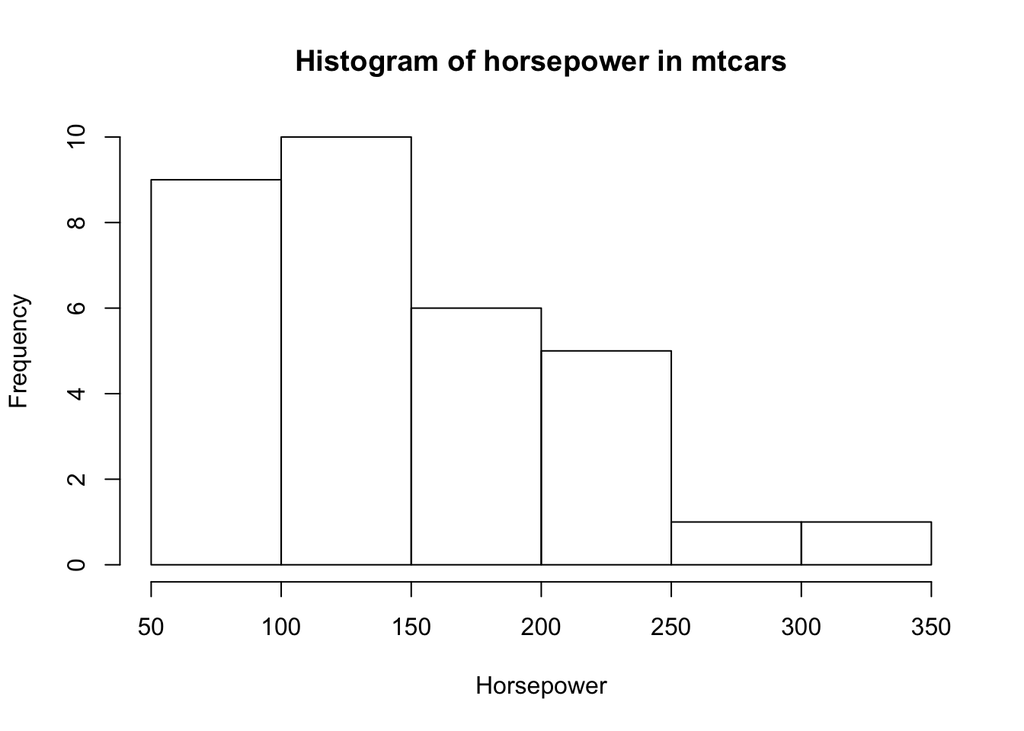

```r
# please put your answer here
# this code chunk should have a figure output
hist(mtcars$hp, main = "Histogram of horsepower in mtcars", xlab = "Horsepower")
```

2. 在資料集中，共有4、6、8三種不同的汽缸數。請整理出一個3 x 3的資料表（請命名為df.hp，並用tibble呈現）。表格的列（row）是三種（4、6、8）不同的汽缸數，表格的欄（column）分別是（1）配備該汽缸數的車子有幾款（變項名稱請用`n`），以及這些車的（2）馬力平均數（變項名稱請用`hp_avg`），和（3）馬力的標準差（變項名稱請用`hp_std`）。

```r
# please put your answer here
df.hp <- mtcars %>%
  select(cyl, hp) %>%
  group_by(cyl) %>%
  summarise(n = length(cyl), hp_avg = mean(hp), hp_std = sd(hp))
# please show the results with the line below
print(df.hp)
```

```
## # A tibble: 3 x 4
##     cyl     n    hp_avg   hp_std
##   <dbl> <int>     <dbl>    <dbl>
## 1     4    11  82.63636 20.93453
## 2     6     7 122.28571 24.26049
## 3     8    14 209.21429 50.97689
```

## 2.3 分析NASA Server log (20%)

這題將使用一個伺服器記錄文字檔 `access_log_nasa_95_1k.txt`，它是1995年7月NASA WWW伺服器的存取記錄(access log)。 該檔案只擷取全部記錄的前1000行，每一行就是一筆存取記錄，其格式如下：

```
<來源> - - [<時間>] "<方法> <路徑> <通訊協定>" <狀態> <回應大小>
burger.letters.com - - [01/Jul/1995:00:18:45 -0400] "GET /images/NASA-logosmall.gif HTTP/1.0" 304 0
```

請您完成以下問題：

1. 請找出「路徑」欄位包含 `/images/` （可能在路徑的開頭或中間）的記錄共有幾行（請將結果命名為變數`n.images`）。
2. 請找出「來源」欄位是以`.jp`結尾的記錄共有幾行（請將結果命名為變數`n.jp`）。 請注意有些「路徑」欄位中包含.jpg，但他們不該算入此題的行數。

```r
# please put your answer here
df <- readr::read_file("/Volumes/BaseQi/Problem/access_log_nasa_95_1k.txt")
df <- strsplit(df, "\n")
df <- unlist(df)
m <- gregexpr("/images/", df)
dfout <- regmatches(df, m)
n.images <- length(unlist(dfout))
m <- gregexpr("\\.jp ", df)
dfout <- regmatches(df, m)
n.jp <- length(unlist(dfout))
# please show the results with the line below
item2.ans <- paste(
    sprintf("number of requests where '/images/' was in url: %d", n.images),
    sprintf("                   where source originated from jp: %d", n.jp), sep="\n")
cat(item2.ans)
```

```
## number of requests where '/images/' was in url: 418
##                    where source originated from jp: 15
```

## 2.4 請下載文本並計算詞頻 (10%)

這題將使用一首歌的歌詞當作文本（lyrics.txt）。該文本是以UTF-8編碼的中文文字檔。請您按照以下步驟計算每個詞的使用次數：

- 請用jiebaR的內建辭典斷詞，並計算每個詞的出現次數。
- 請將詞和其出現次數製作成一個資料表（請用tibble資料表，並命名為df.lyrics），資料表的每一列（row）就是一個詞。該資料表共有兩欄，第一欄（column）是詞字串本身（如你、我、的），請將它命名為`word`；第二欄是出現次數，請將它命名為`freq`。請去除掉僅出現一次的詞，並將該資料表按照`freq`欄位的值從大到小排序。

```r
# please put your answer here
library(tibble)
df <- readr::read_file("/Volumes/BaseQi/Problem/lyrics.txt")
seq <- worker()
df <- seq[df]
df.lyrics <- freq(df)
df.lyrics <- df.lyrics %>%
  filter(freq > 1) %>%
  arrange(desc(freq))
colnames(df.lyrics) <- c("word", "freq")
df.lyrics <- as.tibble(df.lyrics)
# please show the results with the line below
print(df.lyrics)
```

```
## # A tibble: 32 x 2
##     word  freq
##    <chr> <dbl>
##  1    我    14
##  2    了    12
##  3    愛     9
##  4    是     6
##  5  因為     6
##  6  我們     6
##  7    多     4
##  8    的     4
##  9  過往     3
## 10    些     3
## # ... with 22 more rows
```